# TCGA-BRCA RNAseq

Sung Rye Park

2024-06-16

### Project Introduction

HCC70 and Mesothelin (MSLN)

### Introduction

Flow cytometry result link

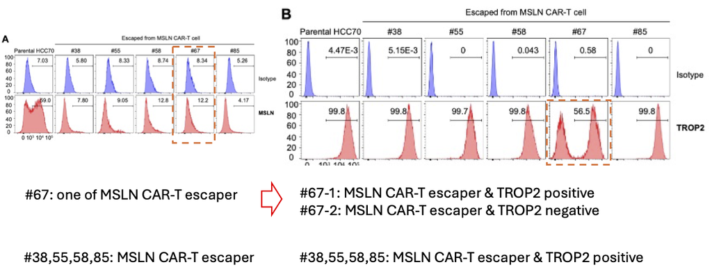

Interestingly, these MSLN CAR-T escapers are TROP2 positive except #67 (Figure 1). Thus we can use TROP2 CAR-T cells to target these tumor cells.

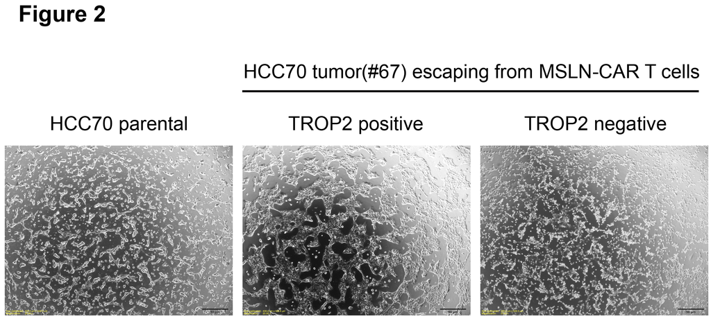

**The #67-1 and #67-2 display the different growth patterns on cultures.**

| **Category** | **TROP2 Positive** | **TROP2 Negative** |
| --- | --- | --- |
| **Cell Density** | Uniformly high; some cells are significantly larger. | Extremely high; closely packed cells. |
| **Cell Shape and Structure** | Large cells with clear boundaries and broad areas. | Irregular shapes and sizes, some compressed. |
| **Growth and Adaptation Strategies** | Vigorous growth and high adaptability. | Adaptation to high density and irregular growth, maybe stressed?. |

**Email discussions**

The ongoing experiments and plans includes: 1) As you suggested, I will confirm the MSLN level by qPCR assay. 2) I will validate that the TROP2 negative from escapers #67 are indeed tumor cells by STR genotyping. 3) As Thanh suggested, I labeled the TROP2 positive and TROP2 negative cells from escapers #67 with Luciferase and will compare their metastasis ability in vivo mice model.

Thus, can you please help dissect the differentially expressed genes (DEGs), upregulated and downregulated signaling between TROP2 high and TROP2 low tumor populations, as well as cell membrane proteins/receptor proteins that are highly expressed in the TROP2 low tumor populations?

### TCGA-BRCA data

TCGA-BRCA MSLN/TROP2/STING1 Expression